# Practical Machine Learning Assignment

Iker Otermin

1/23/2017

Using devices such as Jawbone Up, Nike FuelBand, and Fitbit it is now possible to collect a large amount of data about personal activity relatively inexpensively. These type of devices are part of the quantified self movement – a group of enthusiasts who take measurements about themselves regularly to improve their health, to find patterns in their behavior, or because they are tech geeks. One thing that people regularly do is quantify how much of a particular activity they do, but they rarely quantify how well they do it. In this project, your goal will be to use data from accelerometers on the belt, forearm, arm, and dumbell of 6 participants. They were asked to perform barbell lifts correctly and incorrectly in 5 different ways.

The goal of the project to predict the manner in which they did the exercise, which is the “classe” variable.

## Loading the data

```r
## Loading the datasets
### Training data
tdata <- read.csv("pml-training.csv", na.strings = c("NA", "", "#DIV/0!"))
### Testing data
testdata <- read.csv("pml-testing.csv", na.strings = c("NA", "", "#DIV/0!"))
### Training data set overview
str(tdata)
```

```
## 'data.frame':    19622 obs. of  160 variables:
##  $ X                       : int  1 2 3 4 5 6 7 8 9 10 ...
##  $ user_name               : Factor w/ 6 levels "adelmo","carlitos",..: 2 2 2 2 2 2 2 2 2 2 ...
##  $ raw_timestamp_part_1    : int  1323084231 1323084231 1323084231 1323084232 1323084232 1323084232 1323084232 1323084232 1323084232 1323084232 ...
##  $ raw_timestamp_part_2    : int  788290 808298 820366 120339 196328 304277 368296 440390 484323 484434 ...
##  $ cvtd_timestamp          : Factor w/ 20 levels "02/12/2011 13:32",..: 9 9 9 9 9 9 9 9 9 9 ...
##  $ new_window              : Factor w/ 2 levels "no","yes": 1 1 1 1 1 1 1 1 1 1 ...
##  $ num_window              : int  11 11 11 12 12 12 12 12 12 12 ...
##  $ roll_belt               : num  1.41 1.41 1.42 1.48 1.48 1.45 1.42 1.42 1.43 1.45 ...
##  $ pitch_belt              : num  8.07 8.07 8.07 8.05 8.07 8.06 8.09 8.13 8.16 8.17 ...
##  $ yaw_belt                : num  -94.4 -94.4 -94.4 -94.4 -94.4 -94.4 -94.4 -94.4 -94.4 -94.4 ...
##  $ total_accel_belt        : int  3 3 3 3 3 3 3 3 3 3 ...
##  $ kurtosis_roll_belt      : num  NA NA NA NA NA NA NA NA NA NA ...
##  $ kurtosis_picth_belt     : num  NA NA NA NA NA NA NA NA NA NA ...
##  $ kurtosis_yaw_belt       : logi  NA NA NA NA NA NA ...
```

[output cut: 86 more lines]

```r
## Loading the libraries

library(AppliedPredictiveModeling)
library(caret)
```

```r
library(ggplot2)
library(rpart)
library(MASS)
library(Hmisc)
library(psych)
library(klaR)
library(rattle)
```

## Data manipulation and cleaning

We see that there is a number of variables that provide no information for our prediction analysis, such as date-time related variables and usernames. But a significant amount of variables contain no information at all and become of no use either. Therefore we will proceed to cleaning the data by removing variables with near to zero variables in both training and testing data sets.

```r
##cleaning training data
nzv_cols <- nearZeroVar(tdata)
if(length(nzv_cols) > 0) tdata <- tdata [, -nzv_cols]

trainingclean <- tdata[, colSums(is.na(tdata)) < nrow(tdata) * 0.95]
trainingclean <- trainingclean[,-(1:6)]
str(trainingclean)
```

```
## 'data.frame':    19622 obs. of  53 variables:
##  $ roll_belt           : num  1.41 1.41 1.42 1.48 1.48 1.45 1.42 1.42 1.43 1.45 ...
##  $ pitch_belt          : num  8.07 8.07 8.07 8.05 8.07 8.06 8.09 8.13 8.16 8.17 ...
##  $ yaw_belt            : num  -94.4 -94.4 -94.4 -94.4 -94.4 -94.4 -94.4 -94.4 -94.4 -94.4 ...
##  $ total_accel_belt    : int  3 3 3 3 3 3 3 3 3 3 ...
##  $ gyros_belt_x        : num  0 0.02 0 0.02 0.02 0.02 0.02 0.02 0.02 0.03 ...
##  $ gyros_belt_y        : num  0 0 0 0 0.02 0 0 0 0 0 ...
##  $ gyros_belt_z        : num  -0.02 -0.02 -0.02 -0.03 -0.02 -0.02 -0.02 -0.02 -0.02 0 ...
##  $ accel_belt_x        : int  -21 -22 -20 -22 -21 -21 -22 -22 -20 -21 ...
##  $ accel_belt_y        : int  4 4 5 3 2 4 3 4 2 4 ...
##  $ accel_belt_z        : int  22 22 23 21 24 21 21 21 24 22 ...
##  $ magnet_belt_x       : int  -3 -7 -2 -6 -6 0 -4 -2 1 -3 ...
##  $ magnet_belt_y       : int  599 608 600 604 600 603 599 603 602 609 ...
##  $ magnet_belt_z       : int  -313 -311 -305 -310 -302 -312 -311 -313 -312 -308 ...
##  $ roll_arm            : num  -128 -128 -128 -128 -128 -128 -128 -128 -128 -128 ...
```

[output cut: 39 more lines]

```r
##cleaning testing data
nzvtest_cols <- nearZeroVar(testdata)
if(length(nzvtest_cols) > 0) testdata <- testdata [, -nzvtest_cols]

testclean <- testdata[, colSums(is.na(testdata)) < nrow(testdata) * 0.95]
testclean <- testclean[,-(1:6)]
str(testclean)
```

```
## 'data.frame':    20 obs. of  53 variables:
##  $ roll_belt           : num  123 1.02 0.87 125 1.35 -5.92 1.2 0.43 0.93 114 ...
##  $ pitch_belt          : num  27 4.87 1.82 -41.6 3.33 1.59 4.44 4.15 6.72 22.4 ...
##  $ yaw_belt            : num  -4.75 -88.9 -88.5 162 -88.6 -87.7 -87.3 -88.5 -93.7 -13.1 ...
##  $ total_accel_belt    : int  20 4 5 17 3 4 4 4 4 18 ...
##  $ gyros_belt_x        : num  -0.5 -0.06 0.05 0.11 0.03 0.1 -0.06 -0.18 0.1 0.14 ...
##  $ gyros_belt_y        : num  -0.02 -0.02 0.02 0.11 0.02 0.05 0 -0.02 0 0.11 ...
##  $ gyros_belt_z        : num  -0.46 -0.07 0.03 -0.16 0 -0.13 0 -0.03 -0.02 -0.16 ...
##  $ accel_belt_x        : int  -38 -13 1 46 -8 -11 -14 -10 -15 -25 ...
##  $ accel_belt_y        : int  69 11 -1 45 4 -16 2 -2 1 63 ...
##  $ accel_belt_z        : int  -179 39 49 -156 27 38 35 42 32 -158 ...
##  $ magnet_belt_x       : int  -13 43 29 169 33 31 50 39 -6 10 ...
##  $ magnet_belt_y       : int  581 636 631 608 566 638 622 635 600 601 ...
##  $ magnet_belt_z       : int  -382 -309 -312 -304 -418 -291 -315 -305 -302 -330 ...
##  $ roll_arm            : num  40.7 0 0 -109 76.1 0 0 0 -137 -82.4 ...
```

[output cut: 39 more lines]

Next we will create a data partition, splitting the data for dedicating 70% of the training dataset to train our model, and 30% to test our model.

```r
inTrain <- createDataPartition( y = trainingclean$classe, p = 0.7, list = FALSE)

training <- trainingclean[inTrain, ]
testing <- trainingclean[-inTrain,]
dim(training)
```

```
## [1] 13737    53
```

```r
dim(testing)
```

```
## [1] 5885   53
```

## Building our model:

### Random Forest

We will build our model by Random Forest approach. In random forests, there is no need for cross-validation or a separate test set to get an unbiased estimate of the test set error. It is estimated internally.

```r
## Random Forest

set.seed(82)
modrf <- train(classe~., data = training, method = "rf", prox = TRUE)
predrf <- predict(modrf, newdata = testing)
confusionMatrix(testing$classe, predrf)
```

```
## Confusion Matrix and Statistics
##
##           Reference
## Prediction    A    B    C    D    E
##          A 1672    1    1    0    0
##          B    7 1129    3    0    0
##          C    0   10 1012    4    0
##          D    0    0   19  944    1
##          E    0    1    5    3 1073
##
## Overall Statistics
##
##                Accuracy : 0.9907
##                  95% CI : (0.9879, 0.993)
##     No Information Rate : 0.2853
##     P-Value [Acc > NIR] : < 2.2e-16
##
##                   Kappa : 0.9882
##  Mcnemar's Test P-Value : NA
##
## Statistics by Class:
##
##                      Class: A Class: B Class: C Class: D Class: E
## Sensitivity            0.9958   0.9895   0.9731   0.9926   0.9991
## Specificity            0.9995   0.9979   0.9971   0.9959   0.9981
## Pos Pred Value         0.9988   0.9912   0.9864   0.9793   0.9917
## Neg Pred Value         0.9983   0.9975   0.9942   0.9986   0.9998
## Prevalence             0.2853   0.1939   0.1767   0.1616   0.1825
## Detection Rate         0.2841   0.1918   0.1720   0.1604   0.1823
## Detection Prevalence   0.2845   0.1935   0.1743   0.1638   0.1839
## Balanced Accuracy      0.9977   0.9937   0.9851   0.9943   0.9986
```

```r
predict(modrf, newdata=testclean)
```

```
##  [1] B A B A A E D B A A B C B A E E A B B B
## Levels: A B C D E
```

The model has a very high accuracy of above .99, and a very low out of the sample error rate.

```r
## Out of the sample error rate
1-sum(predrf == testing$classe) / length(predrf)
```

```
## [1] 0.009345794
```

It is, however, a very time-consuming model. We will reduce the variables building a new model that contains the most important seven variables.

```r
varImp(modrf)
```

```
## rf variable importance
##
##   only 20 most important variables shown (out of 52)
##
##                      Overall
## roll_belt             100.00
## pitch_forearm          57.99
## yaw_belt               56.33
## roll_forearm           45.56
## pitch_belt             45.20
## magnet_dumbbell_y      44.86
## magnet_dumbbell_z      44.28
## accel_dumbbell_y       22.02
## accel_forearm_x        19.32
## magnet_dumbbell_x      16.65
## roll_dumbbell          16.65
## magnet_belt_z          14.50
## accel_belt_z           14.47
## magnet_forearm_z       14.41
## accel_dumbbell_z       14.33
## total_accel_dumbbell   13.57
## magnet_belt_y          11.98
## magnet_belt_x          11.60
## gyros_belt_z           10.62
## yaw_arm                10.26
```

```r
## Reduced Random Forest model
modrfred <- train(classe~roll_belt+pitch_forearm+yaw_belt+magnet_dumbbell_z+pitch_belt +
                    magnet_dumbbell_y+roll_forearm, data = training, method="rf", prox=TRUE)
summary(modrfred)
```

```
##                 Length    Class      Mode
## call                    5 -none-     call
## type                    1 -none-     character
## predicted           13737 factor     numeric
## err.rate             3000 -none-     numeric
## confusion              30 -none-     numeric
## votes               68685 matrix     numeric
## oob.times           13737 -none-     numeric
## classes                 5 -none-     character
## importance              7 -none-     numeric
## importanceSD            0 -none-     NULL
## localImportance         0 -none-     NULL
## proximity       188705169 -none-     numeric
## ntree                   1 -none-     numeric
## mtry                    1 -none-     numeric
## forest                 14 -none-     list
## y                   13737 factor     numeric
## test                    0 -none-     NULL
## inbag                   0 -none-     NULL
## xNames                  7 -none-     character
## problemType             1 -none-     character
## tuneValue               1 data.frame list
## obsLevels               5 -none-     character
```

```r
predrfred <- predict(modrfred, newdata = testing)
confusionMatrix(testing$classe, predrfred)
```

```
## Confusion Matrix and Statistics
##
##           Reference
## Prediction    A    B    C    D    E
##          A 1647    8   15    4    0
##          B   13 1102   14    4    6
##          C    1   14 1005    6    0
##          D    0    0   12  951    1
##          E    0    5    4    5 1068
##
## Overall Statistics
##
##                Accuracy : 0.981
##                  95% CI : (0.9771, 0.9843)
##     No Information Rate : 0.2822
##     P-Value [Acc > NIR] : < 2.2e-16
##
##                   Kappa : 0.9759
##  Mcnemar's Test P-Value : NA
##
## Statistics by Class:
##
##                      Class: A Class: B Class: C Class: D Class: E
## Sensitivity            0.9916   0.9761   0.9571   0.9804   0.9935
## Specificity            0.9936   0.9922   0.9957   0.9974   0.9971
## Pos Pred Value         0.9839   0.9675   0.9795   0.9865   0.9871
## Neg Pred Value         0.9967   0.9943   0.9907   0.9961   0.9985
## Prevalence             0.2822   0.1918   0.1784   0.1648   0.1827
## Detection Rate         0.2799   0.1873   0.1708   0.1616   0.1815
## Detection Prevalence   0.2845   0.1935   0.1743   0.1638   0.1839
## Balanced Accuracy      0.9926   0.9842   0.9764   0.9889   0.9953
```

```r
predict(modrfred, newdata=testclean)
```

```
##  [1] B A B A A E D B A A B C B A E E A B B B
## Levels: A B C D E
```

```r
## Out of sample error

1-sum(predrfred == testing$classe) / length(predrfred)
```

```
## [1] 0.01903144
```

This model has an Accuracy almost as high as the previous model, and since this is more time-efficient, we will select this model over the previous one.

### Decission Tree: rpart

An alternative approach using rpart.

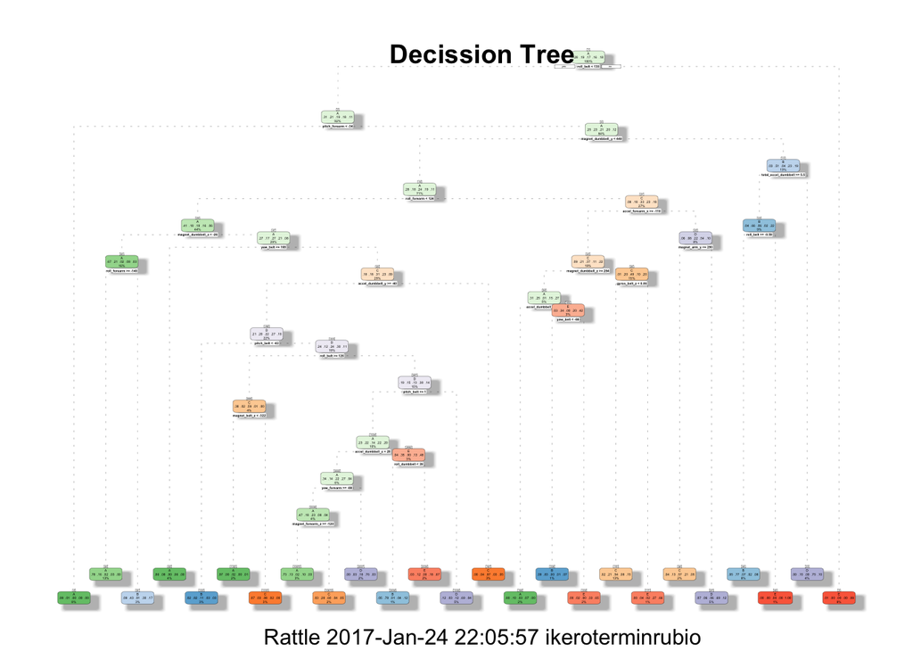

```r
## rpart

set.seed(125)
moddt <- rpart ( classe ~ ., method = "class", data = training)

fancyRpartPlot(moddt, main = "Decission Tree")
```

```r
preddt <- predict(moddt, newdata = testing, type = "class")

confusionMatrix(testing$classe, data = preddt)
```

```
## Confusion Matrix and Statistics
##
##           Reference
## Prediction    A    B    C    D    E
##          A 1508  182   28   68   13
##          B   51  658   56   70   81
##          C   40  204  883   91  142
##          D   64   72   58  662   79
##          E   11   23    1   73  767
##
## Overall Statistics
##
##                Accuracy : 0.7609
##                  95% CI : (0.7498, 0.7718)
##     No Information Rate : 0.2845
##     P-Value [Acc > NIR] : < 2.2e-16
##
##                   Kappa : 0.6971
##  Mcnemar's Test P-Value : < 2.2e-16
##
## Statistics by Class:
##
##                      Class: A Class: B Class: C Class: D Class: E
## Sensitivity            0.9008   0.5777   0.8606   0.6867   0.7089
## Specificity            0.9309   0.9456   0.9018   0.9445   0.9775
## Pos Pred Value         0.8382   0.7183   0.6493   0.7080   0.8766
## Neg Pred Value         0.9594   0.9032   0.9684   0.9390   0.9371
## Prevalence             0.2845   0.1935   0.1743   0.1638   0.1839
## Detection Rate         0.2562   0.1118   0.1500   0.1125   0.1303
## Detection Prevalence   0.3057   0.1556   0.2311   0.1589   0.1487
## Balanced Accuracy      0.9159   0.7617   0.8812   0.8156   0.8432
```

```r
## Out of the sample error rate

1-sum(preddt == testing$classe) / length(preddt)
```

```
## [1] 0.2390824
```

Despite being a quite solid model, this model predicts much worse than the random forest models as we can see on the accuracy and sample error rate.

## Conclusion

The model selected is the reduced random forest model.